# Elliptic Partial Differential Equations

### Reminder (in 1D)

Take the **Poisson equation** in one dimensions: $$ \dfrac{\partial^2 \phi}{\partial x^2} = f, $$ with boundary conditions: $$ \phi(0) = \phi(1) = 0 $$ Using second order finite difference (central) scheme leads to the following formulation: $$ \dfrac{\phi_{i-1}-2\phi_i+\phi_{i+1}}{\Delta^2} = f_i $$

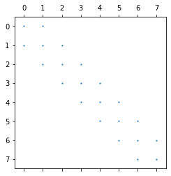

```python
import numpy as np
import scipy.sparse as sp
import math
import matplotlib.pylab as plt
from mpl_toolkits import mplot3d

L = 1
n = 10
x = np.linspace(0, L, num = n)

A = sp.diags([1, -2, 1], [-1, 0, 1], (n-2, n-2) )


plt.spy(A, markersize=1)
plt.show()
```

- Without loss of generality, the problem is discretized in a rectangular domain in the $(x, y)$ plane using a uniformly spaced mesh
- $M + 1$ grid points in the $x$ direction $(x_i, \; i = 0, 1, 2, 3, . . . , M)$
  - $M – 1$ interior points,
  - Boundaries are located at $x_0$ and $x_M$ respectively.
- $N + 1$ points are used in the $y$ direction.
- The second derivatives in the $\nabla^2$ are approximated by second-order finite difference operators
- For simplicity assume that $\Delta_x = \Delta_y = \Delta$
- Equation for $\phi_{i,j}$ becomes: $$ \phi_{i+1,j} - 4\phi_{i,j} + \phi_{i-1,j} + \phi_{i,j+1} + \phi_{i,j-1} = \Delta^2f_{i,j} $$

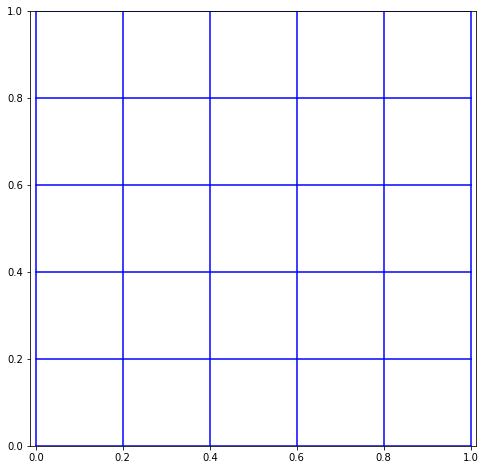

```python
m    = 6
n    = 6
L    = 1
x    = np.linspace(0, L, num = m)
y    = np.linspace(0, L, num = n)


plt.figure(figsize=(8,8))
X, Y = np.meshgrid(x, y)
plt.plot(X, Y, 'b-')
plt.plot(X.T, Y.T, 'b-')
plt.axis('equal')
plt.xlim(0,L)
plt.ylim(0,L)
plt.show()
```

Common ordering, not accounting for BC's

[figure not shown]

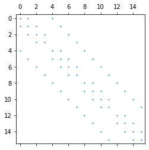

```python
# A second order derivative matrix in 1D
G = sp.diags([-1, 2, 1], [-1, 0, 1], (n-2, n-2) )

# A second order derivative matrix in 2D
G1  = sp.diags([-1, 2, 1], [-1, 0, 1], (m-2, m-2) )
Gx  = sp.kron(sp.eye(n-2), G1 )
G2  = sp.diags([-1, 2, 1], [-1, 0, 1], (n-2, n-2) )
Gy  = sp.kron(G2, sp.eye(m-2) )

A = Gx + Gy

plt.spy(A, markersize=1)
plt.show()
```

An alternative ordering is the red-black or checkerboard ordering

[figure not shown]

Resulting system of equations

[figure not shown]

- Block structure.
- The red-black ordering exploits the fact that computing an update for a “red” grid value only requires surrounding “black” grid values.
- This property is especially appealing when solving elliptic equations on a parallel computer architecture, since the update of the red values can be separated from the update of the black values and can thus be assigned to different processors.

## Point Jacobi Method

[figure not shown]

## Gauss-Seidel Method

[figure not shown]

## Succesive over relaxation scheme

- To optimize convergence, select $\omega$ such that the largest eigenvalue is minimized.
- $\dfrac{d\lambda}{d\omega} = 0$ does not have a solution.
- An absolute minimum exist, when the argument under tha square root is zero.

[figure not shown]

- With $\mu_{max} = 0.9945$ (largest eigenvalue of the point Jacobi method, which dependa on the number of grid points used). This value correspons to a mesh of $31\times 31$.
- And $$ \omega_{opt} = \frac{2}{1+\sqrt{1-\mu_{max}^2}} $$

[figure not shown]